# Assignment3Final

Neli Noykova

June 15, 2017

# MULTIPLE CORRESPONDANCE ANALYSIS - Assignment 3

# The data

As during the Assignment set 1. here we again use **Finnish** sample from [ISSP 2012 survey “Family and Changing Gender Roles IV”](http://www.gesis.org/issp/modules/issp-modules-by-topic/family-and-changing-gender-roles/2012/). Original data involve 1171 observations of 8 variables (4 substantive and 4 demographic). All variables are categorical.

The 4 **substantive** variables, which values are measured in 1-5 scale, are:

**A**: Married people are generally happier than unmarried people.  
**B**: People who want children ought to get married.  
**C**: It is all right for a couple to live together without intending to get married.  
**D**: Divorce is usually the best solution when a couple can’t seem to work out their marriage problems.

The **demographic** variables are:  
**g**: gender (1=male, 2=female)  
**a**: age group (1=16-25, 2=26-35, 3=36-45, 4=46-55, 5=56-65, 6= 66+)  
**e**: education (1=Primary, 2=Comprehensive, primary and lower secondary, 3= Post-comprehensive, vocational school or course, 4=General upper secondary education or certificate, 5= Vocational post-secondary non-tertiary education, 6=Polytechnics, 7= University, lower academic degree, BA, 8=University, higher academic degree, MA  
**p**: Living in steady partnership (1=Yes, have partner; live in same household, 2=Yes, have partner; don’t live in same household, 3=No partner)

The data wrangling includes the following changes:

1. The missing data ae removed (this has already been provided). The number of observations without missing data is N=924.
2. We again use a combined variable **ga = 6*(g-1) + a**. The combined variable** ga** describes the interaction of gender and age categories.

## Graphical overview of the data and summaries of the variables

The preliminary treated data look as:

```r
Finland <- read.table("Finland.txt")
Finland$ga <- 6*(Finland$g-1) + Finland$a
head(Finland)
```

```
##   A B C D g a e p ga
## 1 3 3 1 2 1 2 4 3  2
## 2 3 2 3 2 1 4 2 3  4
## 3 3 3 1 3 1 3 8 1  3
## 4 3 2 2 3 2 2 6 1  8
## 5 2 2 2 3 2 4 5 1 10
## 6 3 3 1 3 1 3 7 3  3
```

```r
dim(Finland)
```

```
## [1] 924   9
```

```r
str(Finland)
```

```
## 'data.frame':    924 obs. of  9 variables:
##  $ A : int  3 3 3 3 2 3 3 2 2 3 ...
##  $ B : int  3 2 3 2 2 3 3 3 3 3 ...
##  $ C : int  1 3 1 2 2 1 1 1 2 3 ...
##  $ D : int  2 2 3 3 3 3 2 2 3 3 ...
##  $ g : int  1 1 1 2 2 1 2 2 2 2 ...
##  $ a : int  2 4 3 2 4 3 1 2 5 4 ...
##  $ e : int  4 2 8 6 5 7 4 8 7 5 ...
##  $ p : int  3 3 1 1 1 3 3 3 1 3 ...
##  $ ga: num  2 4 3 8 10 3 7 8 11 10 ...
```

```r
library(FactoMineR)
library(tidyr)
library(ggplot2)
library(dplyr)
keep_columns <- c("A", "B", "C", "D", "g", "a", "e", "p", "ga")
Finland <- dplyr::select(Finland, one_of(keep_columns))
summary(Finland)
```

```
##        A               B               C               D
##  Min.   :1.000   Min.   :1.000   Min.   :1.000   Min.   :1.000
##  1st Qu.:2.000   1st Qu.:2.000   1st Qu.:1.000   1st Qu.:2.000
##  Median :3.000   Median :3.000   Median :2.000   Median :2.000
##  Mean   :3.193   Mean   :3.025   Mean   :1.835   Mean   :2.503
##  3rd Qu.:4.000   3rd Qu.:4.000   3rd Qu.:2.000   3rd Qu.:3.000
##  Max.   :5.000   Max.   :5.000   Max.   :5.000   Max.   :5.000
##        g               a               e               p
##  Min.   :1.000   Min.   :1.000   Min.   :1.000   Min.   :1.000
##  1st Qu.:1.000   1st Qu.:2.000   1st Qu.:3.000   1st Qu.:1.000
##  Median :2.000   Median :4.000   Median :5.000   Median :1.000
##  Mean   :1.563   Mean   :3.644   Mean   :4.527   Mean   :1.563
##  3rd Qu.:2.000   3rd Qu.:5.000   3rd Qu.:6.000   3rd Qu.:3.000
##  Max.   :2.000   Max.   :6.000   Max.   :8.000   Max.   :3.000
##        ga
##  Min.   : 1.000
##  1st Qu.: 4.000
##  Median : 7.000
##  Mean   : 7.021
##  3rd Qu.:10.000
##  Max.   :12.000
```

We present data graphically as barplots using ggplot() function.

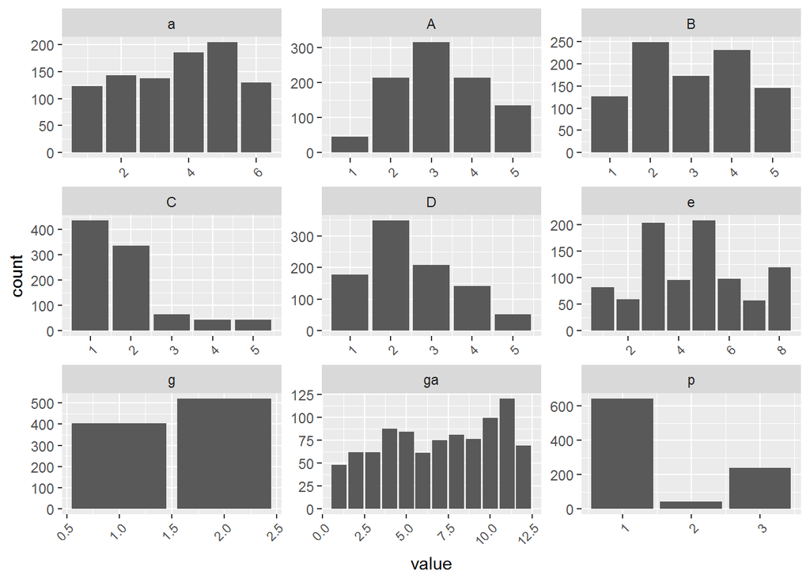

```r
gather(Finland) %>% ggplot(aes(value)) + facet_wrap("key", scales = "free") + geom_bar()+theme(axis.text.x = element_text(angle = 45, hjust = 1, size = 8))
```

# Nonlinear MCA: The package homals in R

There are two main constrained forms of MCA: canonical MCA and nonlinear MCA. Canonical MCA use explanatory variables to explain set of response variables, while in classical MCA there is no restriction imposed by explanatory variables since all variables are assumed to be response variables.

Nonlinear MCA is also assumed to be a constrained form of MCA because it is obtained from common MCA (known also as homogeneity analysis) by imposing restrictions on the variable ranks and levels as well as defined set of variables.

The most important advantages of nonlinear over linear MCA are that except truly numeric nonlinear MCA incorporates nominal and ordinal variables, and additionally can discover nonlinear relationships between variables.

In nonlinear MCA the variables could be nominal, ordinal or true numeric. Nominal variables consist of unordered categories. Since principal components are weighted sums of the original variables, nominal variables could not be analyzed using standard linear PCA. Ordinal variables consist of ordered categories, for example as we have also used, a Likert-type scale. Such scale values are not truly numeric because intervals between consecutive categories are not equal. Although ordinal variables display more structure than nominal ones, these variables still do not possess traditional numeric properties. The true numeric variables can be viewed as categorical with *c* categories, where *c* indicates the number of different observed values. Both ratio and interval variables are considered numeric in nonlinear PCA.

Linear MCA is suitable for variables, all measured as numeric. It is possible to exist nonlinear relationships between some of these variables. Then nonlinear MCA will be more appropriate approach.

Nonlinear PCA converts categories into numeric values because the variance could be established only for numeric values. This process is called quantification. Thus correlations are not computed between observed variables, but between quantified variables. Therefore the correlation matrix in nonlinear PCA is not fixed and depends on the type of quantification chosen for every variable.

The type of quantification is called analysis level. Different analysis levels imply different requirements.

Nonlinear MCA in R could be provided by using the **homals** package. This package performs simple homogeneity analysis, which corresponds to MCA. The package **homals** also provide some extensions to MCA, including nonlinear MCA. Nonlinear PCA could be provided using the function **homals** and setting appropriate options.

In the example below we use “ordinal” analysis level because the substantive variables are ordinal and the categories are given in Likert-type scale.

```r
require(homals)
#algebraically, the geometric concept of dimensionality is related to
#the rank of the matrix, which has to be reduced.
#rank - Which quantification ranks. Default is number of dimensions ndim
#level - Which quantification levels. Possible values are "nominal", "ordinal",
#"numerical", and "polynomial" which can be defined as
#single character (if all variable are of the same level) or
#as vector which length corresponds to the number of variables

Finland.nlpca <- homals(Finland[,1:4], rank=1, level="ordinal")
```

## 1. Transformation plots

Next the transformation plot is drawn. The horizontal axis (x) of the plot displays the categories (1 to 5) of the ordinal substantive variables. On the vertical axis (y) the category quantification for every substantive variable (A-D) are shown.

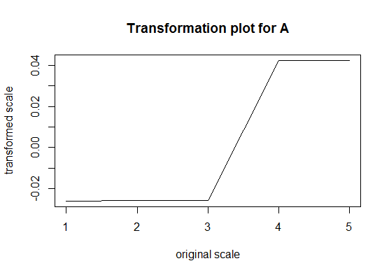

Figure 1A

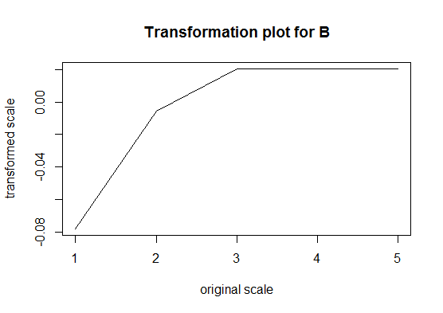

Figure 1B

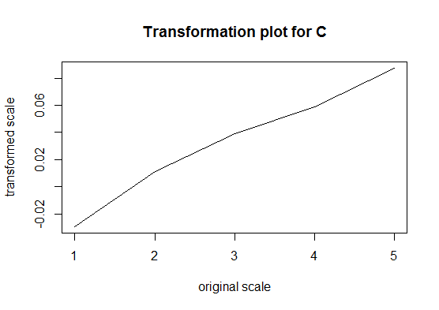

Figure 1C

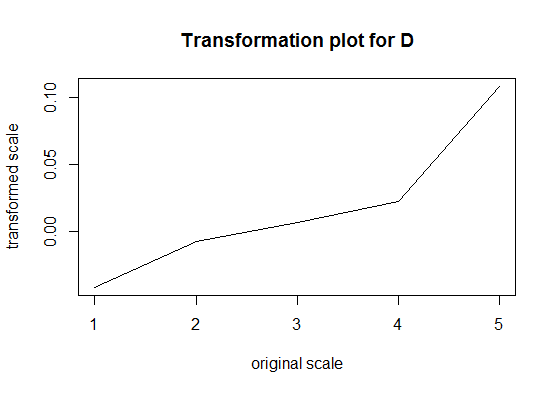

Figure 1D

```r
#Transformation plot: Plots the original (categorical) scale against
#the transformed (metric) scale on each dimension over the categories
#of each variable separately.
plot(Finland.nlpca, plot.type="trfplot")    # relationship of transformed scale with 1-to-5 scale
```

## 2.Category plots

This plot represent a quantified variable by displaying its category points in principal component space, where the axes are given by the principal components. Here a variable is represented by a vector going through the origin (0,0) (which is also the mean of the quantified variable) and the point with as coordinates the component loadings for the variable. The component loadings are correlations between the quantified variables and the principal components, and the sum of squared component loadings indicates the variance accounted for (VAF) by the principal component. The category points are also positioned on the variable vector, and their coordinates are found by multiplying the category quantifications by the corresponding loadings on the first (for the x-coordinate) and the second (for the y-coordinate) component.  
Categories with quantifications above the mean lie on the side of the origin on which the component loadings point is positioned, and categories with quantifications below the mean lie in the opposite direction. The total length of the variable vector does not indicate the importance of the variable.

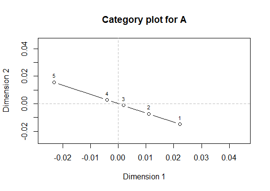

Figure 2A

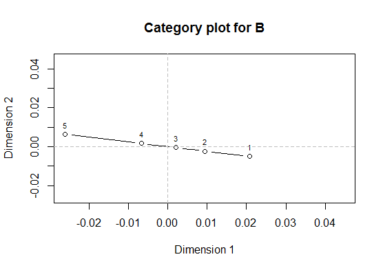

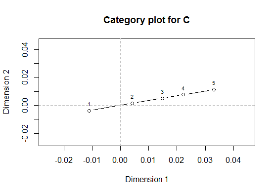

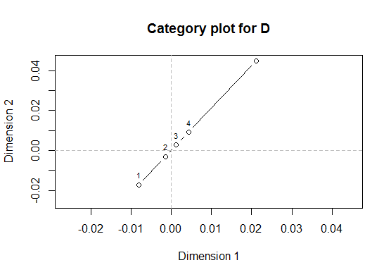

Figure 2D

```r
#2. Category plot: Plots the rank-restricted category quantifications for
#each variable separately.
plot(Finland.nlpca, plot.type="catplot")
```

In these plots the loading point is not shown. I do not know how to interpret the nonlinear transformations, which lead to these 4 category plots.

## 3.Component loadings plot

In these plots only the loading vectors (origin and loading point) are displayed. Here the variables with relatively long vectors fit well into the solution and variables with relatively short vectors fit badly. When vectors are long, the cosines of the angles between the vectors indicate the correlation between the quantified variables. The length of the variable vector from the origin up to the component loading point is an indication of the variable’s total variance accounted for (VAF). Thus VAF can be interpreted as the amount of information retained when variables are represented in a lower dimensional space. Nonlinear transformations reduce the dimensionality necessary to represent the variables satisfactory.

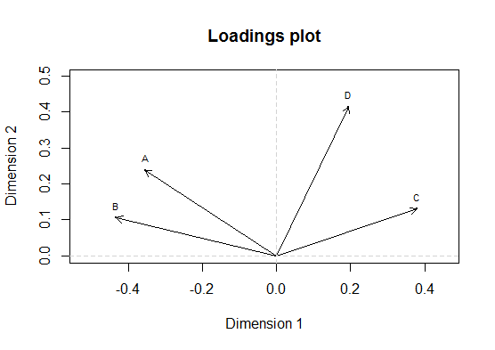

Figure 3

```r
#3. Loadings plot: Plots the loadings of the variables and connects them with the origin.
plot(Finland.nlpca, plot.type="loadplot")
```

In this example the longest length has a variable vector for D. Other variable vector lengths are very similar and not much shorter than D loading vector.

## 4.Vector plot

In this plot all cases (object scores) are projected onto a straight line defined by each rank restricted category quantified variable. Here except the straight line, plotted in the category plots, also all object scores are shown.

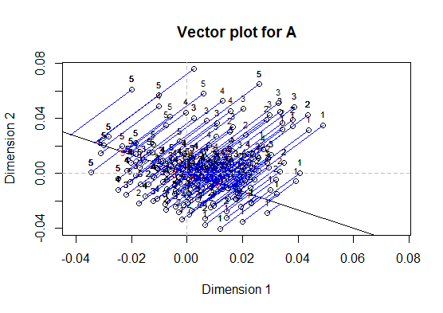

Figure 4A

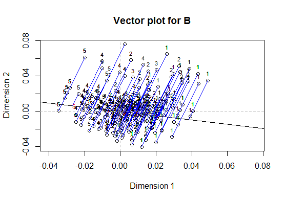

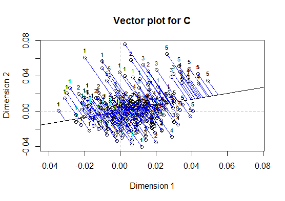

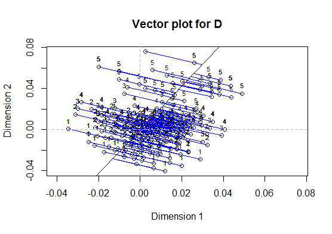

```r
#4. Vector plot: cases projected onto straight line defined by each variable
plot(Finland.nlpca, plot.type="vecplot")
```

##5.Loss plot

The loss plot shows the rank-restricted category quantifications against the unrestricted for each variable separately. It actually compares MCA and NLPCA.

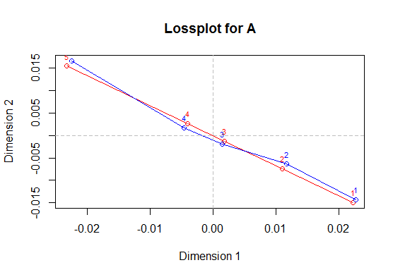

Figure 5A

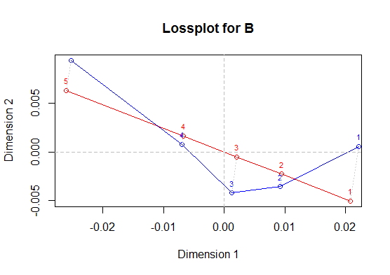

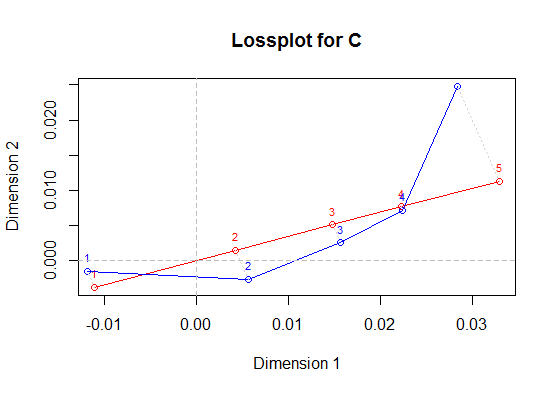

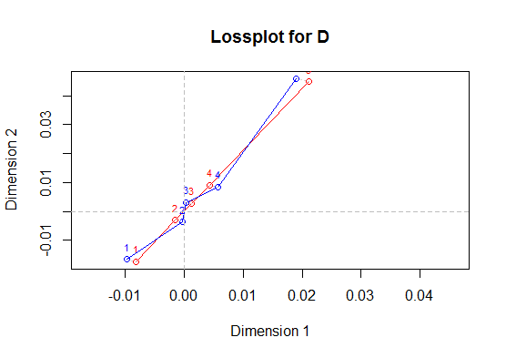

```r
plot(Finland.nlpca, plot.type="lossplot")
```

From these plots we see that the linear and nonlinear MCA results are very near for variables A and D, while both model outputs differ quite a lot for the variables B and C. This could mean that linear model assumption for variables A and D is appropriate.

## 6. Object plot

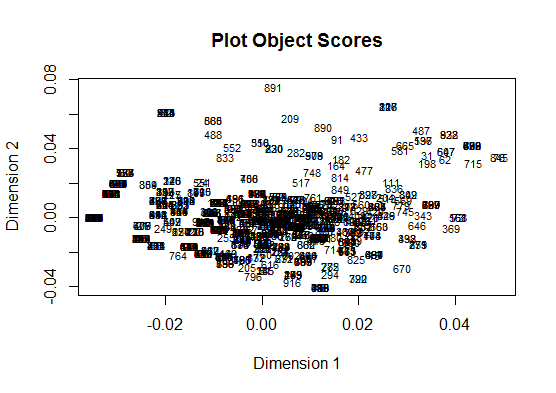

Figure 6

```r
plot(Finland.nlpca, plot.type="objplot")
```

## 7. Label plot

It is similar to the previous object plot. In the label plot the object scores are also plotted, but now for each variable separately with the corresponding category labels. It looks like contour lines forced to be straight & parallel

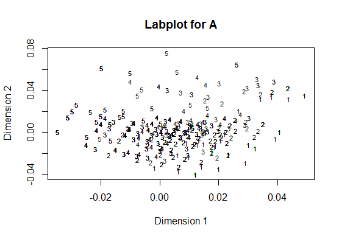

Figure 7A

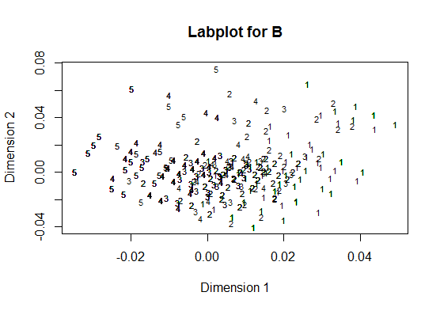

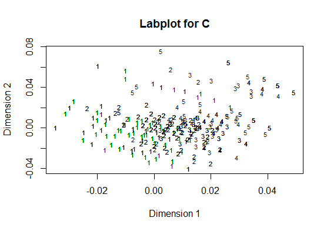

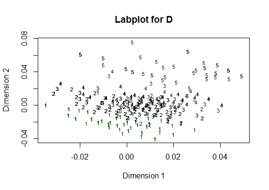

```r
plot(Finland.nlpca, plot.type="labplot")
```

#8. Graph plot.

It is a joint plot with connections between scores/quantifications. So, except the object scores, plotted on object plot, the variable quantifications are also shown. It should be noted that this plot works only for small data sets. Even in the provided example ot is already quite difficult to observe the plotted relationships.

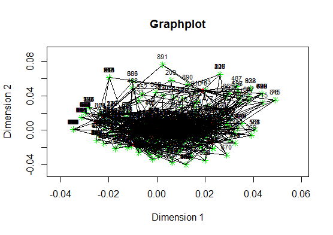

```r
plot(Finland.nlpca, plot.type="graphplot")
```

##9. Voronoi plot. It produces a category plot with Voronoi regions. Looks like contour lines forced to be straight and parallel.

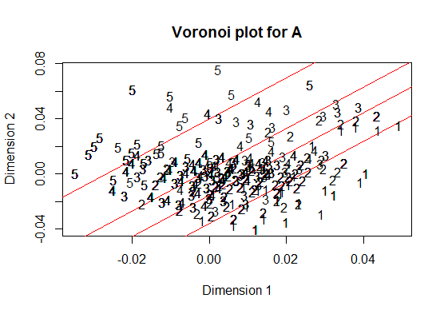

Figure 9A

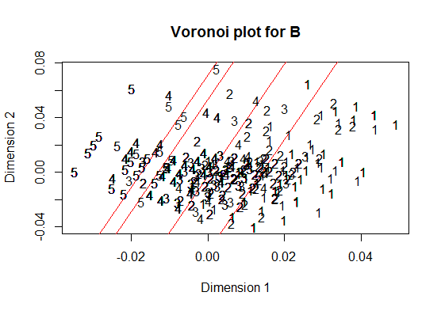

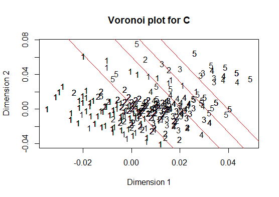

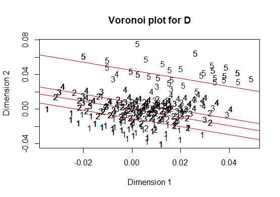

Figure 9D

```r
plot(Finland.nlpca, plot.type="vorplot")
```